# R Notebook

```r
pacman::p_load(tidyverse,
               FactoMineR,factoextra,
               gridExtra, plotly)

data <- read.csv("real_estate_db.csv")
colnames(data)
```

```
 [1] "UID"                         "BLOCKID"                     "SUMLEVEL"                    "COUNTYID"                    "STATEID"
 [6] "state"                       "state_ab"                    "city"                        "place"                       "type"
[11] "primary"                     "zip_code"                    "area_code"                   "lat"                         "lng"
[16] "ALand"                       "AWater"                      "pop"                         "male_pop"                    "female_pop"
[21] "rent_mean"                   "rent_median"                 "rent_stdev"                  "rent_sample_weight"          "rent_samples"
[26] "rent_gt_10"                  "rent_gt_15"                  "rent_gt_20"                  "rent_gt_25"                  "rent_gt_30"
[31] "rent_gt_35"                  "rent_gt_40"                  "rent_gt_50"                  "universe_samples"            "used_samples"
[36] "hi_mean"                     "hi_median"                   "hi_stdev"                    "hi_sample_weight"            "hi_samples"
[41] "family_mean"                 "family_median"               "family_stdev"                "family_sample_weight"        "family_samples"
[46] "hc_mortgage_mean"            "hc_mortgage_median"          "hc_mortgage_stdev"           "hc_mortgage_sample_weight"   "hc_mortgage_samples"
[51] "hc_mean"                     "hc_median"                   "hc_stdev"                    "hc_samples"                  "hc_sample_weight"
[56] "home_equity_second_mortgage" "second_mortgage"             "home_equity"                 "debt"                        "second_mortgage_cdf"
[61] "home_equity_cdf"             "debt_cdf"                    "hs_degree"                   "hs_degree_male"              "hs_degree_female"
[66] "male_age_mean"               "male_age_median"             "male_age_stdev"              "male_age_sample_weight"      "male_age_samples"
[71] "female_age_mean"             "female_age_median"           "female_age_stdev"            "female_age_sample_weight"    "female_age_samples"
[76] "pct_own"                     "married"                     "married_snp"                 "separated"                   "divorced"
```

Given the high dimensionality of the data, then it would be useful to apply factor analysis to see which variables capture the highest level of variance in the dataset.

Skip on using summary() on the data since the output would be massively bulky and unkind to the naked eye.

Find those variables that are numeric first and observe some of their distributions.

```r
num <- select_if(data, is.numeric)
colnames(num)
```

```
 [1] "UID"                         "SUMLEVEL"                    "COUNTYID"                    "STATEID"                     "zip_code"
 [6] "area_code"                   "lat"                         "lng"                         "ALand"                       "AWater"
[11] "pop"                         "male_pop"                    "female_pop"                  "rent_mean"                   "rent_median"
[16] "rent_stdev"                  "rent_sample_weight"          "rent_samples"                "rent_gt_10"                  "rent_gt_15"
[21] "rent_gt_20"                  "rent_gt_25"                  "rent_gt_30"                  "rent_gt_35"                  "rent_gt_40"
[26] "rent_gt_50"                  "universe_samples"            "used_samples"                "hi_mean"                     "hi_median"
[31] "hi_stdev"                    "hi_sample_weight"            "hi_samples"                  "family_mean"                 "family_median"
[36] "family_stdev"                "family_sample_weight"        "family_samples"              "hc_mortgage_mean"            "hc_mortgage_median"
[41] "hc_mortgage_stdev"           "hc_mortgage_sample_weight"   "hc_mortgage_samples"         "hc_mean"                     "hc_median"
[46] "hc_stdev"                    "hc_samples"                  "hc_sample_weight"            "home_equity_second_mortgage" "second_mortgage"
[51] "home_equity"                 "debt"                        "second_mortgage_cdf"         "home_equity_cdf"             "debt_cdf"
[56] "hs_degree"                   "hs_degree_male"              "hs_degree_female"            "male_age_mean"               "male_age_median"
[61] "male_age_stdev"              "male_age_sample_weight"      "male_age_samples"            "female_age_mean"             "female_age_median"
[66] "female_age_stdev"            "female_age_sample_weight"    "female_age_samples"          "pct_own"                     "married"
[71] "married_snp"                 "separated"                   "divorced"
```

```r
# Function to calculate % of missing data
pMiss <- function(x) {sum(is.na(x))/length(x)*100}

# Identify columns with NA
apply(num, 2, pMiss)
```

```
                        UID                    SUMLEVEL                    COUNTYID                     STATEID                    zip_code
                  0.0000000                   0.0000000                   0.0000000                   0.0000000                   0.0000000
                  area_code                         lat                         lng                       ALand                      AWater
                  0.0000000                   0.0000000                   0.0000000                   0.0000000                   0.0000000
                        pop                    male_pop                  female_pop                   rent_mean                 rent_median
                  0.0000000                   0.0000000                   0.0000000                   1.1837048                   1.1837048
                 rent_stdev          rent_sample_weight                rent_samples                  rent_gt_10                  rent_gt_15
                  1.1837048                   1.1837048                   1.1837048                   1.1862670                   1.1862670
                 rent_gt_20                  rent_gt_25                  rent_gt_30                  rent_gt_35                  rent_gt_40
                  1.1862670                   1.1862670                   1.1862670                   1.1862670                   1.1862670
                 rent_gt_50            universe_samples                used_samples                     hi_mean                   hi_median
                  1.1862670                   0.0000000                   0.0000000                   0.9992314                   0.9992314
                   hi_stdev            hi_sample_weight                  hi_samples                 family_mean               family_median
                  0.9992314                   0.9992314                   0.9992314                   1.1119652                   1.1119652
               family_stdev        family_sample_weight              family_samples            hc_mortgage_mean          hc_mortgage_median
                  1.1119652                   1.1119652                   1.1119652                   2.1547528                   2.1547528
          hc_mortgage_stdev   hc_mortgage_sample_weight         hc_mortgage_samples                     hc_mean                   hc_median
                  2.1547528                   2.1547528                   2.1547528                   2.2802972                   2.2802972
                   hc_stdev                  hc_samples            hc_sample_weight home_equity_second_mortgage             second_mortgage
                  2.2802972                   2.2802972                   2.2802972                   1.7345632                   1.7345632
                home_equity                        debt         second_mortgage_cdf             home_equity_cdf                    debt_cdf
                  1.7345632                   1.7345632                   1.7345632                   1.7345632                   1.7345632
                  hs_degree              hs_degree_male            hs_degree_female               male_age_mean             male_age_median
                  0.7045862                   0.7404561                   0.8403792                   0.6994620                   0.6994620
             male_age_stdev      male_age_sample_weight            male_age_samples             female_age_mean           female_age_median
                  0.6994620                   0.6994620                   0.6994620                   0.7737638                   0.7737638
           female_age_stdev    female_age_sample_weight          female_age_samples                     pct_own                     married
                  0.7737638                   0.7737638                   0.7737638                   0.9992314                   0.7045862
                married_snp                   separated                    divorced
                  0.7045862                   0.7045862                   0.7045862
```

## filter out the missing observations on variables of interest

```r
f1 <- num %>%
  filter(!is.na(rent_mean)) %>%
  filter(!is.na(debt)) %>%
  filter(!is.na(male_age_mean)) %>%
  filter(!is.na(female_age_mean))
```

```r
x <- f1[, c("rent_mean", "debt",
            "male_age_mean", "female_age_mean")]

summary(x)
```

```
   rent_mean           debt        male_age_mean   female_age_mean
 Min.   : 159.1   Min.   :0.0000   Min.   :16.14   Min.   :18.68
 1st Qu.: 742.7   1st Qu.:0.5393   1st Qu.:35.06   1st Qu.:36.93
 Median : 952.5   Median :0.6487   Median :38.32   Median :40.36
 Mean   :1054.2   Mean   :0.6299   Mean   :38.35   Mean   :40.33
 3rd Qu.:1259.0   3rd Qu.:0.7383   3rd Qu.:41.35   3rd Qu.:43.56
 Max.   :3962.3   Max.   :1.0000   Max.   :80.11   Max.   :79.84
```

## plot the complete data

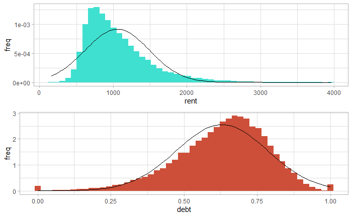

```r
x <- ggplot(f1, aes(x = rent_mean)) +
  geom_histogram(aes(y = ..density..),
                 bins = 50, fill = "turquoise") +
  stat_function(fun = dnorm,
                color = "black",
                args = list(mean = mean(f1$rent_mean),
                            sd = sd(f1$rent_mean))) +
  theme_light() +
  labs(x = "rent", y = "freq")

y <- ggplot(f1, aes(x = debt)) +
  geom_histogram(aes(y = ..density..),
                 bins = 50, fill = "tomato3") +
  stat_function(fun = dnorm,
                color = "black",
                args = list(mean = mean(f1$debt),
                            sd = sd(f1$debt))) +
  theme_light() +
  labs(x = "debt", y = "freq")

grid.arrange(x, y)
```

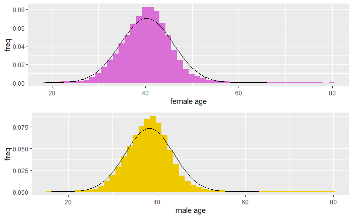

```r
w <- ggplot(f1, aes(x = female_age_mean))+
  geom_histogram(aes(y = ..density..),
                 bins = 50,
                 fill = "orchid") +
  stat_function(fun = dnorm,
                color = "black",
                args = list(mean = mean(f1$female_age_mean),
                            sd = sd(f1$female_age_mean))) +
  labs(x = "female age",
       y = "freq")

z <- ggplot(f1, aes(x = male_age_mean))+
  geom_histogram(aes(y = ..density..),
                 bins = 50,
                 fill = "gold2") +
  stat_function(fun = dnorm,
                color = "black",
                args = list(mean = mean(f1$male_age_mean),
                            sd = sd(f1$male_age_mean))) +
  labs(x = "male age",
       y = "freq")

grid.arrange(w, z)
```

```r
sums <- num %>% select(rent_mean, debt,
                        female_age_mean,
                        male_age_mean) %>%
  filter(!is.na(rent_mean), !is.na(debt),
         !is.na(female_age_mean),
         !is.na(male_age_mean))

#do.call(cbind, lapply(sums, summary))
lapply(sums, summary)
```

```
$rent_mean
   Min. 1st Qu.  Median    Mean 3rd Qu.    Max.
  159.1   742.7   952.5  1054.2  1259.0  3962.3

$debt
   Min. 1st Qu.  Median    Mean 3rd Qu.    Max.
 0.0000  0.5393  0.6487  0.6299  0.7383  1.0000

$female_age_mean
   Min. 1st Qu.  Median    Mean 3rd Qu.    Max.
  18.68   36.93   40.36   40.33   43.56   79.84

$male_age_mean
   Min. 1st Qu.  Median    Mean 3rd Qu.    Max.
  16.14   35.06   38.32   38.35   41.35   80.11
```

## means and medians

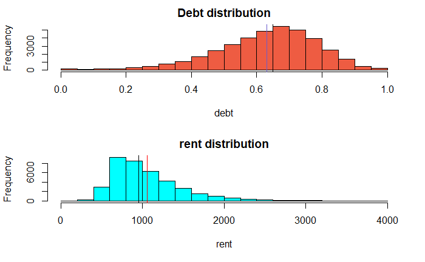

```r
par(mfrow = c(2, 1))
# debt

hist(sums$debt,
           col = "tomato2",
           xlab = "debt",
           main = "Debt distribution") %>%
abline(v = mean(sums$debt),
       col = "slateblue") %>%
abline(v = median(sums$debt),
       col = "black")

# rent
hist(sums$rent_mean,
           col = "cyan", xlab = "rent",
           main = "rent distribution") %>%
abline(v = mean(sums$rent_mean),
       col = "red") %>%
abline(v = median(sums$rent_mean),
       col = "black")
```

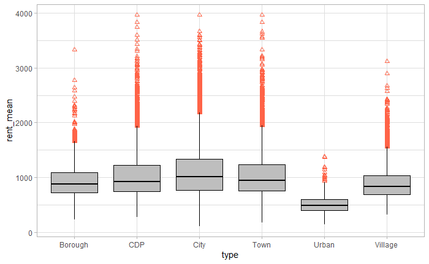

```r
rent_type <- data[, c("rent_mean", "type")] %>%
  filter(!is.na("rent_mean"),
         !is.na("type"))


ggplot(rent_type,
       aes(x = type,
       y = rent_mean)) +
  geom_boxplot(fill = "gray",
               color = "black",
               outlier.color = "tomato",
               outlier.shape = 2) +
  theme_light()
```

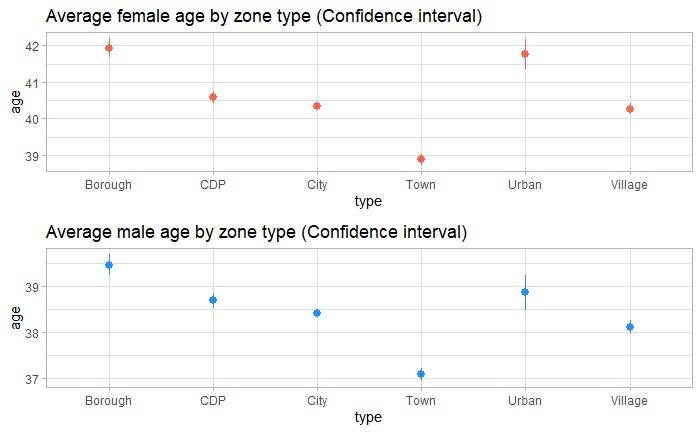

```r
# Confidence interval plots
fm_type <- data[, c("female_age_mean",
                    "male_age_mean",
                    "type")] %>%
  filter(!is.na("female_age_mean"), !is.na("male_age_mean"), !is.na("type"))

x2 <- ggplot(fm_type, aes(x = type,
                          y = female_age_mean)) +
  stat_summary(fun.data = mean_cl_normal,
               color = "tomato") +
  theme_light() +
  labs(title = "Average female age by zone type (Confidence interval)",
       x = "type",
       y = "age")

y2 <- ggplot(fm_type, aes(x = type,
                          y = male_age_mean)) +
  stat_summary(fun.data = mean_cl_normal,
               color = "dodgerblue") +
  theme_light() +
  labs(title = "Average male age by zone type (Confidence interval)",
       x = "type",
       y = "age")

grid.arrange(x2, y2)
```

## Inferential statistics

Calculate 95% confidence interval for population mean

```r
# sample size
n <- sums %>% select(male_age_mean) %>%
  nrow()

# sd
male_std <- sums %>% summarize(std = sd(male_age_mean))

#
x_bar <- sums %>% summarize(avg = mean(male_age_mean))

standard_error <- -qnorm(0.025)*male_std/sqrt(n)

# lower and upper
low <- x_bar - standard_error
high <- x_bar + standard_error

# female sample size

nf <- sums %>% select(female_age_mean) %>%
  nrow()

female_std <- sums %>%  filter(!is.na(female_age_mean)) %>% summarize(std = sd(female_age_mean))

x_bar <- sums %>%  filter(!is.na(female_age_mean)) %>%
  summarize(avg = mean(female_age_mean))

standard_error <- -qnorm(0.025)*female_std/sqrt(nf)

# lower and upper
low <- x_bar - standard_error
high <- x_bar + standard_error
```

## 95% of random samples from 38, 283 (male and female) will have confidence intervals that have the true population age mean of male and females between ‘high’ and ‘low’

## H0: the true population age mean of females is within the high and low range

## H1: true population age mean of females is NOT within the high and low

```r
set.seed(42)
f_age <- data %>% select(female_age_mean) %>%
  filter(!is.na(female_age_mean))

mu <- mean(f_age$female_age_mean)
n <- 100

x_bar <- mean(sample(f_age$female_age_mean,
                     n))

std <- sd(sample(f_age$female_age_mean,
                 n))

# 95% CI
st_error <- qnorm(0.025)*std/sqrt(n)

# Z-score
z_score <- (x_bar - mu)/st_error
print(paste("Z-score:", z_score))
```

```
[1] "Z-score: -0.029448200784584"
```

```r
# P-value (one & two tailed)
two_tail_pval <- 2*pnorm(-abs(z_score))
one_tail_pval <- two_tail_pval / 2

print(paste0("Two tailed p-value:", two_tail_pval))
```

```
[1] "Two tailed p-value:0.97650713078873"
```

```r
print(paste0("One tailed p-value:", one_tail_pval))
```

```
[1] "One tailed p-value:0.488253565394365"
```

## Insufficient evidence to reject H0

## Contigency tables are used here to summarize the association between various variables

- find if two variables are independent or dependent i.e. their relationship.
- independence is a condition for the central limit theorem.
- Central limit theorem = increasing sample size results in the sample mean approximating a normal distribution.
- Increasing sample size causes the measured sample means to be more closely distributed around the population mean.

```r
# Chi-squared test of independence on categorical variables
cats <- select_if(data, is.factor)

colnames(cats)
```

```
[1] "state"    "state_ab" "city"     "place"    "type"     "primary"
```

```r
tab <- table(cats$type, cats$state)
#summary(tab)
chisq.test(tab)
```

```
Chi-squared approximation may be incorrect
```

```
    Pearson's Chi-squared test

data:  tab
X-squared = 195150, df = 255, p-value < 2.2e-16
```

## p-val is less than 0.05, indicating a strong association

```r
# Chisq test by unique observation in each variable
contingency_tab <- cats %>%
  select(state, type) %>%
  table() %>%
  prop.table() %>%
  round(4)

contingency_tab
```

```
                      type
state                  Borough    CDP   City   Town  Urban Village
  Alabama               0.0000 0.0000 0.0000 0.0157 0.0000  0.0000
  Alaska                0.0000 0.0000 0.0027 0.0000 0.0000  0.0000
  Arizona               0.0000 0.0204 0.0000 0.0000 0.0000  0.0000
  Arkansas              0.0000 0.0000 0.0093 0.0000 0.0000  0.0000
  California            0.0000 0.0000 0.1074 0.0000 0.0000  0.0000
  Colorado              0.0000 0.0000 0.0171 0.0000 0.0000  0.0000
  Connecticut           0.0000 0.0114 0.0000 0.0000 0.0000  0.0000
  Delaware              0.0000 0.0000 0.0000 0.0028 0.0000  0.0000
  District of Columbia  0.0000 0.0000 0.0025 0.0000 0.0000  0.0000
  Florida               0.0000 0.0000 0.0586 0.0000 0.0000  0.0000
  Georgia               0.0000 0.0000 0.0276 0.0000 0.0000  0.0000
  Hawaii                0.0000 0.0045 0.0000 0.0000 0.0000  0.0000
  Idaho                 0.0000 0.0000 0.0038 0.0000 0.0000  0.0000
  Illinois              0.0000 0.0000 0.0000 0.0000 0.0000  0.0408
  Indiana               0.0000 0.0000 0.0205 0.0000 0.0000  0.0000
  Iowa                  0.0000 0.0000 0.0106 0.0000 0.0000  0.0000
  Kansas                0.0000 0.0000 0.0113 0.0000 0.0000  0.0000
  Kentucky              0.0000 0.0000 0.0148 0.0000 0.0000  0.0000
  Louisiana             0.0000 0.0000 0.0156 0.0000 0.0000  0.0000
  Maine                 0.0000 0.0000 0.0049 0.0000 0.0000  0.0000
  Maryland              0.0000 0.0196 0.0000 0.0000 0.0000  0.0000
  Massachusetts         0.0000 0.0000 0.0199 0.0000 0.0000  0.0000
  Michigan              0.0000 0.0375 0.0000 0.0000 0.0000  0.0000
  Minnesota             0.0000 0.0000 0.0179 0.0000 0.0000  0.0000
  Mississippi           0.0000 0.0090 0.0000 0.0000 0.0000  0.0000
  Missouri              0.0000 0.0000 0.0188 0.0000 0.0000  0.0000
  Montana               0.0000 0.0041 0.0000 0.0000 0.0000  0.0000
  Nebraska              0.0000 0.0000 0.0000 0.0000 0.0000  0.0070
  Nevada                0.0000 0.0000 0.0091 0.0000 0.0000  0.0000
  New Hampshire         0.0000 0.0040 0.0000 0.0000 0.0000  0.0000
  New Jersey            0.0000 0.0000 0.0259 0.0000 0.0000  0.0000
  New Mexico            0.0000 0.0000 0.0074 0.0000 0.0000  0.0000
  New York              0.0000 0.0000 0.0657 0.0000 0.0000  0.0000
  North Carolina        0.0000 0.0000 0.0000 0.0000 0.0000  0.0299
  North Dakota          0.0000 0.0000 0.0028 0.0000 0.0000  0.0000
  Ohio                  0.0000 0.0000 0.0000 0.0000 0.0000  0.0394
  Oklahoma              0.0000 0.0141 0.0000 0.0000 0.0000  0.0000
  Oregon                0.0000 0.0000 0.0116 0.0000 0.0000  0.0000
  Pennsylvania          0.0445 0.0000 0.0000 0.0000 0.0000  0.0000
  Puerto Rico           0.0000 0.0000 0.0000 0.0000 0.0125  0.0000
  Rhode Island          0.0000 0.0033 0.0000 0.0000 0.0000  0.0000
  South Carolina        0.0000 0.0000 0.0144 0.0000 0.0000  0.0000
  South Dakota          0.0000 0.0033 0.0000 0.0000 0.0000  0.0000
  Tennessee             0.0000 0.0000 0.0203 0.0000 0.0000  0.0000
  Texas                 0.0000 0.0000 0.0000 0.0709 0.0000  0.0000
  Utah                  0.0000 0.0000 0.0085 0.0000 0.0000  0.0000
  Vermont               0.0000 0.0024 0.0000 0.0000 0.0000  0.0000
  Virginia              0.0000 0.0000 0.0000 0.0258 0.0000  0.0000
  Washington            0.0000 0.0000 0.0000 0.0207 0.0000  0.0000
  West Virginia         0.0000 0.0000 0.0068 0.0000 0.0000  0.0000
  Wisconsin             0.0000 0.0000 0.0188 0.0000 0.0000  0.0000
  Wyoming               0.0000 0.0000 0.0019 0.0000 0.0000  0.0000
```

## T-distribution

- Used for experimenting with small sample sizes
- n < 30

```r
states <- data %>% select(state, rent_mean) %>%
  filter(state == "Texas" | state == "Georgia") %>%
  filter(!is.na(rent_mean))

set.seed(42)
n <- 21
sample <- sample_n(states, n)

Tex <- sample %>%
  filter(state == "Texas")

# Texas test
Tex_n <- Tex %>%
  nrow()

Tex_x_bar <- Tex %>% summarize(avg = mean(rent_mean))

t_score <- abs(qt(0.025, df = 11))

Tex_sd <- Tex %>%
  summarize(sd = sd(rent_mean))

upper <- Tex_x_bar + t_score * (Tex_sd / sqrt(Tex_n))
lower <- Tex_x_bar - t_score * (Tex_sd / sqrt(Tex_n))
upper
```

| avg |
| --- |
| 1262.897 |

```r
lower
```

| avg |
| --- |
| 902.1304 |

## 95% sure the average rent for Texas is between the lower and upper bounds

## Assume the average rent for Georgia is 888

- Find the p-value i.e. amount of evidence to reject null hypothesis

```r
Geo <- states %>% filter(state == "Georgia")

Geo_n <- Geo %>%
  nrow()

Geo_x_bar <- Geo %>% summarize(avg = mean(rent_mean))

Geo_sd <- Geo %>% summarize(sd = sd(rent_mean))

standard_error <- Geo_sd / sqrt(Geo_n)

mu = 888
t_score <- (Geo_x_bar - mu) / standard_error
print(paste0(t_score))
```

```
[1] "6.37136760547347"
```

```r
2*pt(6.371, df = 11, lower.tail = FALSE)
```

```
[1] 5.288613e-05
```

## p-value < 0.05, sufficient evidence to reject null hypothesis

## Difference between two means of independent groups

- Independent groups = 2 separate subject groups
- Assumes 2 groups (populations) have homogeneity of variance
- The groups are normally distributed
- Each value is sampled independently

```
`fun.y` is deprecated. Use `fun` instead.
```

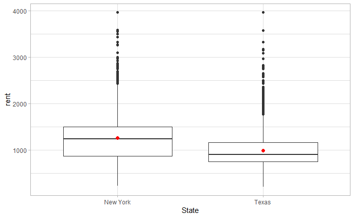

```r
states <- data %>%
  filter(state == "New York" | state == "Texas") %>%
  filter(!is.na(rent_mean))

ggplot(states, aes(x=state, y = rent_mean)) +
  geom_boxplot()+
  stat_summary(fun.y = mean,
               color = "red",
               geom = "point",
               size = 2) +
  theme_light() +
  labs(x = "State", y = "rent")
```

- H0 = no difference between average rent in NY and Texas
- H1 = difference exists

```r
# p-value

NY_n <- states %>%
  filter(state == "New York") %>%
  nrow()

NY_x_bar <- states %>% filter(state == "New York") %>%
  summarize(avg = mean(rent_mean))

NY_sd <- states %>% filter(state == "New York") %>%
  summarize(sd = sd(rent_mean))

# standard error
Tex_se <- Tex_sd/sqrt(Tex_n)
NY_se <- NY_sd/sqrt(NY_n)

standard_error <- sqrt(Tex_se)^2 + sqrt(NY_se)^2

# Point estimate
p_est <- (Tex_x_bar - NY_x_bar)

t_score <- abs((p_est - 0)/standard_error)
t_score <- as.numeric(t_score)

p_val <- 2*pt(t_score, df = 21, lower.tail = FALSE)
p_val
```

```
[1] 0.07127319
```

## No significant evidence available to reject null hypothesis (no difference between average rent in Texas and New York)

## ANOVA tests

- H0 = mean of rent is the same across the sampled group of states
- H1 = at least 2 states are different from each other

```r
state4 <- data %>%
  select(state, rent_mean) %>%
  group_by(state) %>%
  filter(!is.na(rent_mean)) %>%
  filter(state == "New York"| state == "Texas" | state == "Washington" | state == "California") %>%
  summarize(avg = mean(rent_mean), sd = sd(rent_mean), count = n())

state4
```

| state | avg | sd | count |
| --- | --- | --- | --- |
| California | 1468.4532 | 484.5313 | 4151 |
| New York | 1256.3088 | 477.1923 | 2511 |
| Texas | 988.0275 | 368.2253 | 2741 |
| Washington | 1131.9946 | 331.0449 | 805 |

```
`fun.y` is deprecated. Use `fun` instead.
```

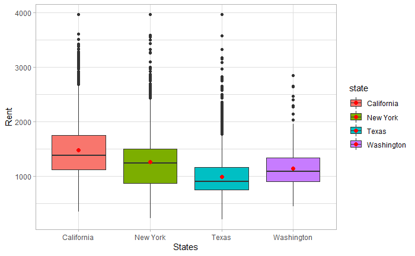

```r
state4 <- data %>%
  select(state, rent_mean) %>%
  filter(!is.na(rent_mean)) %>%
  filter(state == "New York"| state == "Texas" | state == "Washington" | state == "California") %>%
  group_by(state)

ggplot(state4, aes(x = state, y = rent_mean,
                   fill = state)) +
  geom_boxplot() +
  stat_summary(fun.y = mean,
               color = "red",
               geom = "point",
               size = 2) +
  labs(x = "States", y = "Rent") +
  theme_light()
```

```r
NA
```

```r
ungroup4 <- state4 %>%
  ungroup()

anova_state4 <- aov(rent_mean ~ state,
                    data = ungroup4)

summary(anova_state4)
```

```
               Df    Sum Sq   Mean Sq F value Pr(>F)
state           3 3.963e+08 132113437   672.2 <2e-16 ***
Residuals   10204 2.005e+09    196539
---
Signif. codes:  0 ‘***’ 0.001 ‘**’ 0.01 ‘*’ 0.05 ‘.’ 0.1 ‘ ’ 1
```

## Significant evidence to believe that the mean rent is different for at least 2 states.